# Cartograflow

Filtering Matrix with continuous distance criterion for Thematic Flow Mapping

Cartograflow, 2020

2020-05-17

This vignette of `Cartograflow` is dedicated to filtering an Origin-Destination matrix with a continuous distance matrix. The aim is to plot flow less than a maximum distance value, above a minimum distance travelled criterion or on a range of distances.

## Main function

**flowdist**

– `flowdist()` computes a *continous distance* matrix from spatial features (area or points). The result is a matrix of the distances travelled between ODs, with flows filtered or not.

## Useful additional functions for a complete analysis

**flowjointure**

– `flowjointure()` is to performs a spatial join between a flow dataset and a spatial features layer (as a map background) or another matrix

**flowreduct**

– `flowreduct()` is to reduce the flow dataset regarding another matrix, e.g. distances travelled.

- `metric` is the metric of the distance matrix : *continuous* (e.g. for meters) or *ordinal* (e.g. for adjacency).

If the metric is continuous (e.g for filtering flows by kilometric distances travelled), use:

- `d.criteria` is for selecting *dmin* or *dmax* distance criteria for “continuous” metric ; Argument `dmin` is for keeping only flows up to a *dmin* criterion in km ; Argument `dmax` for selecting values less than a *dmax* criterion in km.
- `d` is the value of the selected *dmin* or *dmax* criteria.

Notice that these arguments can be used as a filter criterion in `flowmap()`.

**flowmap**

– `flowmap()` is to plot flows as segments or arrows, by acting on the following arguments:

- `filter` is to filter or not flow’s information or features
- `threshold` is used to set the filtering level of the flows when filter=“True”
- `taille` is the value of the width of the flow feature
- `a.head` is the arrow head parameter (in, out, in and out)
- `a.length` is the length of the edges of the arrow head (in inches)
- `a.angle` is the angle from the shaft of the arrow to the edge of the arrow head
- `a.col` is the arrow’s color
- `plota` is to add spatial features as map background to the flows’s plot
- `add` is to allow to overlay flow features on external spatial features background

## **1. Load datasets**

**Flow dataset**

```r
# Load Statistical information
data<-read.csv2("./data/MOBPRO_ETP.csv",
                header=TRUE,
                sep=";",
                stringsAsFactors=FALSE,
                encoding="UTF-8",
                dec=".",
                check.names=FALSE)
str(data)
```

```
## 'data.frame':    121 obs. of  4 variables:
##  $ i    : chr  "T1" "T1" "T1" "T1" ...
##  $ j    : chr  "T1" "T10" "T11" "T12" ...
##  $ Fij  : int  291058 8297 3889 17064 12163 32682 81129 16622 25317 1962 ...
##  $ count: int  351 43 13 77 52 55 134 63 53 14 ...
```

```r
# Variable typing
data$i<-as.character(data$i)
data$j<-as.character(data$j)
data$Fij<-as.numeric(data$Fij)
data$count<-as.numeric(data$count)

# Selecting useful variables
tabflow<-data%>%select(i,j,Fij)
```

**Geographical dataset**

```r
# Load a list of geo codes
ID_CODE<-read.csv2("./data/COD_GEO_EPT.csv",
                   header=TRUE,
                   sep=";",
                   stringsAsFactors=FALSE,
                   encoding="UTF-8",
                   dec=".",
                   check.names=FALSE)
#head(ID_CODE)

CODE<-ID_CODE%>% dplyr::select(COD_GEO_EPT)

colnames(CODE)<-c("CODGEO")
#head(CODE)

# Map Background
map<-st_read("./data/MGP_TER.shp")
```

## **2. Compute distance matrix**

Function aims first to compute a distance matrix then to reduce the matrix and finally to plot the (filtered) flows

Example is for euclidian distance.

```r
head(tabflow)
```

```
##    i   j    Fij
## 1 T1  T1 291058
## 2 T1 T10   8297
## 3 T1 T11   3889
## 4 T1 T12  17064
## 5 T1  T2  12163
## 6 T1  T3  32682
```

```r
tab<-flowjointure(geom="area",DF.flow=tabflow,origin = "i",destination = "j",
                   bkg=map,id="EPT_NUM",x="X",y="Y")
tab.distance<-flowdist(tab,
                       dist.method = "euclidian",
                       result = "dist")

tab.distance<-tab.distance %>% select(i,j,distance)
tab<-tab %>% select(i,j,ydata)
head(tab.distance)
```

```
##    i   j  distance
## 1 T1  T1     0.000
## 2 T1 T10 11367.443
## 3 T1 T11 17285.787
## 4 T1 T12 12460.261
## 5 T1  T2  9367.284
## 6 T1  T3  9951.666
```

## **3. Flowmap reduction according to distance matrix**

**3.1. Flow reduction according to a maximum distance matrix**

Using for mapping flow less than the maximum distance travelled criterion

```r
#reduce the flow dataset from a selected distance travelled (eg. 8.5 km)
library(rlang)

tab.flow<-flowreduct(tab,
                     tab.distance,
                     metric = "continous",
                     d.criteria = "dmax", #max distance parameter
                     d = 8567)        #max distance value - Q1 : 8567 km

#select for all i,j flow values up to 0
flow.d<-tab.flow %>%
        select(i,j,flowfilter) %>%
        filter(flowfilter !=0)
head(flow.d)
```

```
##     i   j flowfilter
## 1  T1  T8      18756
## 2 T10 T11      11707
## 3 T10  T8       6236
## 4 T10  T9       3497
## 5 T11 T10       9359
## 6 T12  T2       5728
```

**3.2. Flowmap (filtered) according to a maximum distance travelled parameter**

Using the “dmax” distance parameter to plot flows less than the maximum distance criterion (here : 8,5 km)

```r
# Graphic parameters
knitr::opts_chunk$set(fig.width=6, fig.height=6)
par(mar=c(0,0,1,0))
extent <- c(2800000, 1340000, 6400000, 4800000)
resolution<-150

# Overlay a spatial background
par(bg = "NA")

# Add the corresponding background
plot(st_geometry(map), col = NA, border=NA, bg="#dfe6e1")
plot(st_geometry(map), col = "light grey", add=TRUE)


#Flowmap : flow travelled less than 8.5 km  (as the first quartile Q1)

flowmap(tab=flow.d,
        fij="flowfilter",origin.f = "i",destination.f = "j",
        bkg = map,code="EPT_NUM",nodes.X="X",nodes.Y = "Y",
        filter=TRUE,
        taille=8,
        a.head = 1,
        a.length = 0.11,
        a.col="#f7714f",
        add=TRUE)
```

```
## you use the default threshold= 1
```

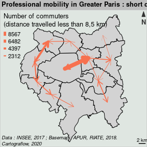

```r
#Map legend
legendPropLines(pos="topleft",
                title.txt="Number of commuters\n(distance travelled less than 8,5 km)",
                title.cex=0.8,
                cex=0.5,
                values.cex= 0.7,
                var=c(min(flow.d$flowfilter),8567),
                col="#f7714f",
                lwd=8,
                frame = FALSE,
                values.rnd = 0
                )


#Map cosmetic
layoutLayer(title = "Professional mobility in Greater Paris : short distance travelled",
            author = "Cartograflow, 2020",
            sources = "Data : INSEE, 2017 ; Basemap : APUR, RIATE, 2018.",
            scale = 2,
            tabtitle = FALSE,
            frame = TRUE,
            col = "grey",
            coltitle ="black"
            )

# north arrow
north("topright")
```

**3.3. Flowmap (filtered) according to a minimum distance travelled parameter**

[output not shown]

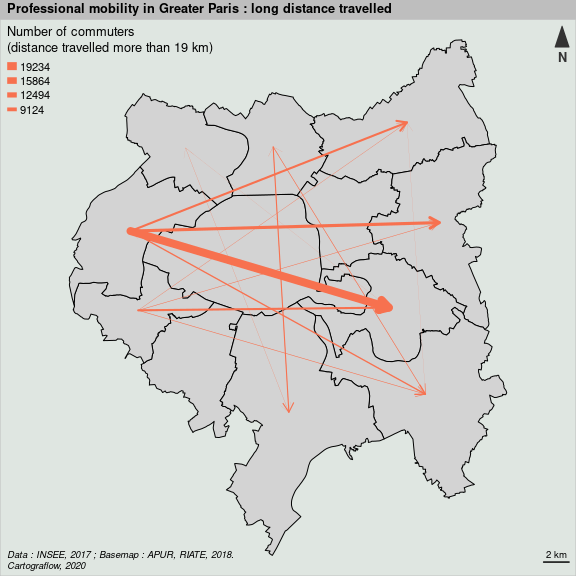

## **4. Flowmap reduction and filtering according to distance matrix**

Use the **“dmax” distance parameter** in association with the **“threshold” flowmap parameter** to map flows between two values (here between the first and third quartiles [Q1 - Q3])

[output not shown]

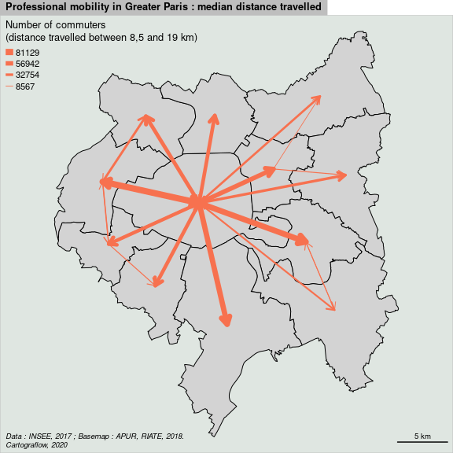

## See also

– cartograflow_general.html  
– cartograflow_concentration.html  
– cartograflow_contiguity.hmtl  
– cartograflow_ordinal_distance.hmtl

## Reference

– Bahoken Francoise (2016), Programmes pour R/Rtudio annexés, in : *Contribution à la cartographie d’une matrix de flux*, Thèse de doctorat, Université Paris 7, pp. 325-346. URL : https://halshs.archives-ouvertes.fr/tel-01273776, pp. 480-520.